# User input() Function

- input() Function Syntax
- String input from user
- Numeric input from user
- Decision based on input from User
- Resources

## input() Function Syntax

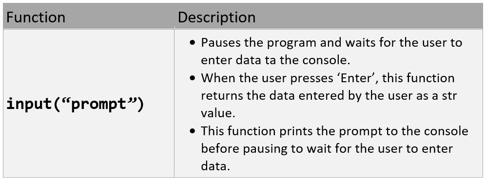

#### Python allows for user input from the keyboard. That means you can ask the user to enter information.

#### You use the input() function to get user input from the console.

#### The returned string value from an input() function is assigned to a string variable.

#### The input() function always returns string data. Even when a number is entered.

## String input from user

```python
userName = input("Enter name: ")       # 'Dave' is entered at the console.
print("Hello, " + userName + "!")
```

```
Enter name: Dave
Hello, Dave!
```

#### Another way to get string input from user

```python
print("What is your name? ")           # 'Dave' is entered at the console.
userName = input()
print("Hello, " + userName + "!")
```

```
What is your name?
Dave
Hello, Dave!
```

## Numeric input from user

- Cast the input to the type of data needed (i.e., int or float)
- NO ValueError Exception Handling was coded here to deal with non-numeric data

```python
print("Input a rate and a distance")

rate = float(input("Rate: "))

distance = float(input("Distance: "))

print("Time:", (distance / rate))
```

```
Input a rate and a distance
Rate: 50
Distance: 5
Time: 0.1
```

#### Attempt to get Numeric input from user

```python
print("Input a rate and a distance")

rate = input("Rate: ")

distance = input("Distance: ")

print("rate = ", type(rate))
print("distance = ", type(distance))

print("Time:", (distance / rate))
```

```
Input a rate and a distance
Rate: 50
Distance: 5
rate =  <class 'str'>
distance =  <class 'str'>
```

```
---------------------------------------------------------------------------
TypeError                                 Traceback (most recent call last)
<ipython-input-11-585baafab273> in <module>
      6 print("rate = ", type(rate))
      7 print("distance = ", type(distance))
----> 8 print("Time:", (distance / rate))

TypeError: unsupported operand type(s) for /: 'str' and 'str'
```

## Decision based input from user

```python
name = input("What is your name? ")

if name == "Dave":
    print("Welcome, good sir. You may enter!")
else:
    print("Who are you?")
```

```
What is your name? Dave
Welcome, good sir. You may enter!
```

## Resources

#### Sources for deeper learning:

1. [W3Schools.com](https://www.w3schools.com/python/python_user_input.asp) Python User Input
1. Getting [Input](https://www.youtube.com/watch?v=1gEZi0uJ3sw) from users. YouTube.com

#### Sources used in this document:

Python [User Input](https://www.w3schools.com/python/python_user_input.asp) from W3Schools.com